# RMA data analysis

Setup chunk: Load data, filter, and generate necessary extra variables. This set of filters eliminates data from the year 2017, for which no SPEI data are available, and data from 1997-1999, for which there are no DSCI data. Generating a standardized data frame as well.

```r
## libraries #####

library(tidyverse)
library(lme4)
library(mgcv)
library(itsadug)
library(reghelper)
library(VGAM)
library(censReg)
library(stargazer)
library(sampleSelection)


# data #####

all_data <- readRDS("../../data/all_data_2020.03.02.rds")

all_data$SSURGO_taxorder_mode[is.na(all_data$SSURGO_taxorder_mode)] <- "Unknown"

all_data <- all_data %>%
  filter(!is.na(july_spei),
         !is.na(DSCI.mean),
         SSURGO_taxorder_mode != "Entisols",
         loss_cost < 300) %>%
  rename(Yield_mg_ha = Yield.bu.acre) %>%
  mutate(Yield_mg_ha = Yield_mg_ha*0.0628) %>%
  group_by(GEOID) %>%
  mutate(County_avg_yield = mean(Yield_mg_ha)) %>%
  ungroup() %>%
  mutate(Yield_diff = ((Yield_mg_ha - County_avg_yield)/County_avg_yield)) %>%
  dplyr::select(Year, GEOID, FIPS, County.name, State.alpha, State,
                Yield_mg_ha,loss_cost, Yield_diff, Acres.harvested,
                starts_with("RMA.drought"), starts_with("soilgrids"), starts_with("SSURGO"),
                starts_with("DSCI"), ends_with("spei"), County_avg_yield) %>%
  rename(Liability.drought = RMA.drought.Liability..US..,
         Indemnity.drought = RMA.drought.Payment.indemnity..US..,
         Count.drought = RMA.drought.Payment.count,
         SOC.ssurgo = SSURGO_soc0_30_mean,
         Clay.ssurgo = SSURGO_claytotal_r_mean,
         Order.ssurgo = SSURGO_taxorder_mode) %>%
  distinct(.) %>%
  mutate(Corn.belt = case_when(State.alpha %in% c("SD", "NE", "MN", "IA", "WI", "IL", "IN", "OH") ~ "CB",
                               TRUE ~ "NCB")) %>%
  as.data.frame(.)

all_data$Count.drought[is.na(all_data$Count.drought)] <- 0
all_data$RMA.drought.Payment.acreage[is.na(all_data$RMA.drought.Payment.acreage)] <- 0


# NOTE - this set of filters eliminates data from the year 2017, for which no SPEI data are available,
# and data from 1997-1999, for which there are no DSCI data

# Generate standardized dataframe ####

scale.2sd <- function(x){
  round((x-mean(x))/(2*sd(x)), digits = 10)
}

all.data.stan <- all_data %>%
  mutate_at(.vars = vars(10:44),.funs = function(x) {if(is.numeric(x)) as.vector(scale.2sd(x)) else x})
```

To start, we’ll do a simple model of indemnities as a function of drought and various soil properties.

```r
m <- all.data.stan %>%
  lmerTest::lmer(data = ., formula = Indemnity.drought ~ july_spei*SOC.ssurgo*Clay.ssurgo +
                   (1|Order.ssurgo),
                 na.action = "na.omit")

summary(m)
```

```
## Linear mixed model fit by REML. t-tests use Satterthwaite's method [
## lmerModLmerTest]
## Formula: Indemnity.drought ~ july_spei * SOC.ssurgo * Clay.ssurgo + (1 |
##     Order.ssurgo)
##    Data: .
##
## REML criterion at convergence: 10841.8
##
## Scaled residuals:
##     Min      1Q  Median      3Q     Max
## -1.9510 -0.3263 -0.1164  0.1091 29.7270
##
## Random effects:
##  Groups       Name        Variance Std.Dev.
##  Order.ssurgo (Intercept) 0.002914 0.05398
##  Residual                 0.213788 0.46237
## Number of obs: 8329, groups:  Order.ssurgo, 6
##
## Fixed effects:
##                                    Estimate Std. Error         df t value
## (Intercept)                      -2.882e-02  2.373e-02  5.244e+00  -1.214
## july_spei                        -3.523e-01  1.063e-02  8.320e+03 -33.161
## SOC.ssurgo                       -8.615e-03  1.384e-02  2.926e+03  -0.623
## Clay.ssurgo                       2.854e-03  1.320e-02  1.303e+03   0.216
## july_spei:SOC.ssurgo             -2.139e-01  2.223e-02  8.317e+03  -9.624
## july_spei:Clay.ssurgo             9.908e-03  2.249e-02  8.319e+03   0.441
## SOC.ssurgo:Clay.ssurgo            1.825e-02  2.768e-02  4.388e+03   0.659
## july_spei:SOC.ssurgo:Clay.ssurgo -8.917e-02  5.423e-02  8.318e+03  -1.644
##                                  Pr(>|t|)
## (Intercept)                         0.276
## july_spei                          <2e-16 ***
## SOC.ssurgo                          0.534
## Clay.ssurgo                         0.829
## july_spei:SOC.ssurgo               <2e-16 ***
## july_spei:Clay.ssurgo               0.660
## SOC.ssurgo:Clay.ssurgo              0.510
## july_spei:SOC.ssurgo:Clay.ssurgo    0.100
## ---
## Signif. codes:  0 '***' 0.001 '**' 0.01 '*' 0.05 '.' 0.1 ' ' 1
##
## Correlation of Fixed Effects:
##             (Intr) jly_sp SOC.ss Cly.ss jl_:SOC. jl_:C. SOC.:C
## july_spei    0.009
## SOC.ssurgo   0.093  0.010
## Clay.ssurgo -0.102  0.009 -0.092
## jly_sp:SOC. -0.002  0.089  0.025 -0.003
## jly_sp:Cly.  0.001 -0.208 -0.021  0.047 -0.283
## SOC.ssrg:C. -0.008 -0.008 -0.097  0.295  0.015    0.011
## jl_:SOC.:C. -0.004 -0.285  0.006  0.001 -0.254    0.504  0.059
```

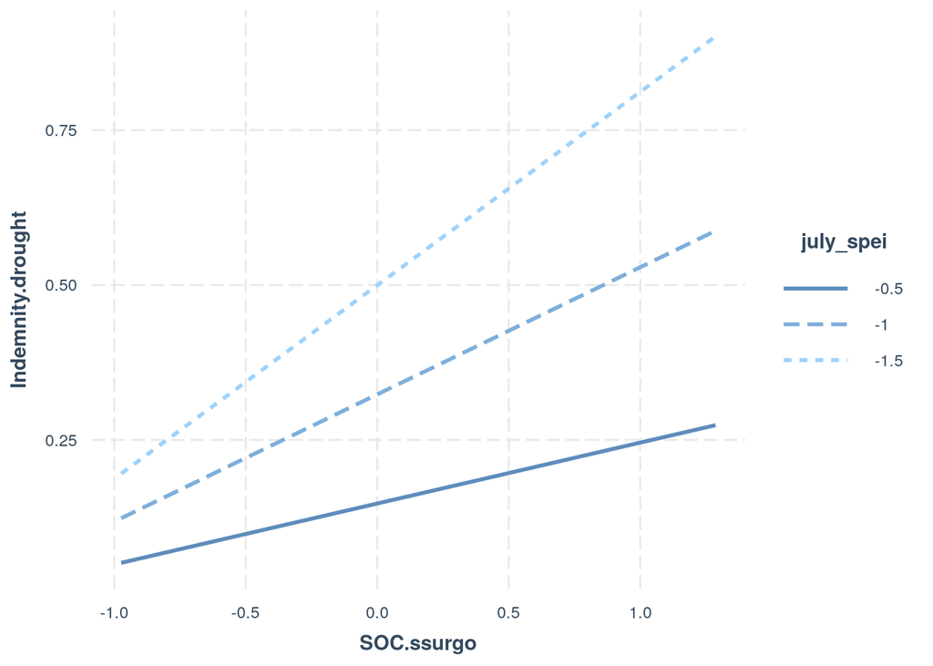

```r
interactions::interact_plot(model = m, pred = SOC.ssurgo, modx = july_spei, modx.values = c(-1.5,-1, -0.5))
```

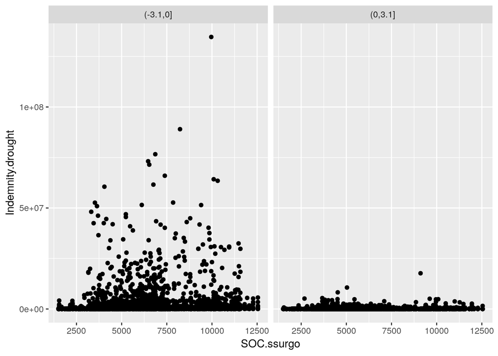

```r
# Facet data into different ranges of july_spei value and plot indemnity ~ SOC
all_data %>%
  mutate(fct = cut(july_spei, breaks = c(-3.1,0,3.1))) %>%
  ggplot(data = ., aes(x = SOC.ssurgo, y = Indemnity.drought)) +
  geom_point() +
  facet_wrap(facets = "fct")
```

In a simple model, drought (july_spei) emerges as significant negative coefficient for indemnities - as july spei goes up, conditions get less droughty, and insurance payments go down. Interestingly, an interaction effect between SOC and july_spei emerges but in a direction that contradicts our hypothesis - SOC interacts with drought in an additive manner, as drought gets worse payouts are higher when SOC is higher. However, this pattern may be explained by the fact that SOC has a positive effect on yields, as demonstrated in our previous analysis, meaning that counties with higher SOC have higher yield potential to begin with and are more likely to be insured under adverse conditions.

Crop insurance is not just purchased at the beginning of the season. Additional coverage can be purchased as the season progresses, meaning growers have the opportunity to respond to bad early season conditions by increasing their insurance coverage.

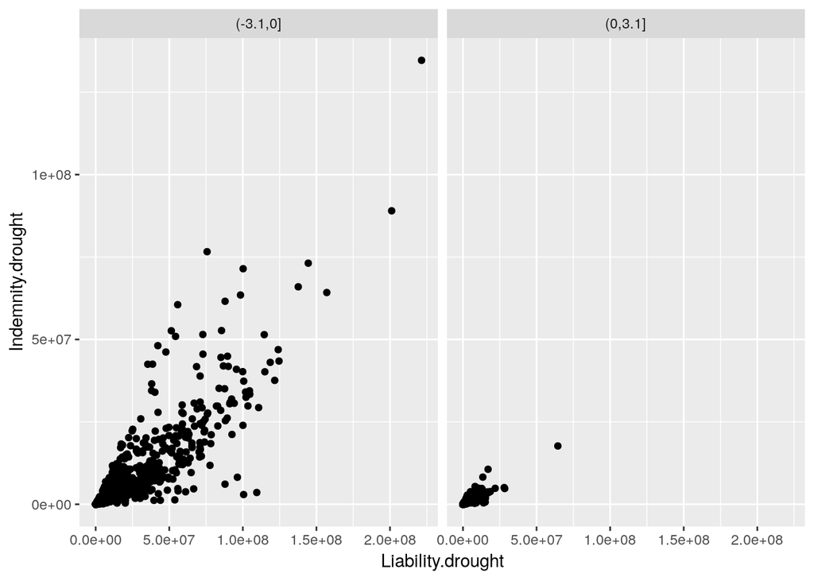

```r
# Facet data into different ranges of july_spei value and plot indemnity ~ liabilties
all_data %>%
  mutate(fct = cut(july_spei, breaks = c(-3.1,0,3.1))) %>%
  ggplot(data = ., aes(x = Liability.drought, y = Indemnity.drought)) +
  geom_point() +
  facet_wrap(facets = "fct")
```

Looking at the relationship between indemnities (payouts) and liabilities (coverage), a strong linear relatioship is apparent, and liabilities are generally much higher under droughty conditions. Given this strong relationship between indemnities and liabilities, we’ll use a modeling approach that accounts for this by modeling the residuals of the linear relationship of indeminities ~ liabilities.

```r
all.data.stan <- all.data.stan %>%
  mutate(liability.resids = as.numeric(residuals(lm(Indemnity.drought ~ Liability.drought, data = all.data.stan))))

m <- all.data.stan %>%
  lmerTest::lmer(data = ., formula = liability.resids ~ july_spei*SOC.ssurgo*Clay.ssurgo +
                   (1|Order.ssurgo),
                 na.action = "na.omit")

summary(m)
```

```
## Linear mixed model fit by REML. t-tests use Satterthwaite's method [
## lmerModLmerTest]
## Formula: liability.resids ~ july_spei * SOC.ssurgo * Clay.ssurgo + (1 |
##     Order.ssurgo)
##    Data: .
##
## REML criterion at convergence: -902.1
##
## Scaled residuals:
##      Min       1Q   Median       3Q      Max
## -17.1898  -0.0795   0.0358   0.1063  26.0330
##
## Random effects:
##  Groups       Name        Variance  Std.Dev.
##  Order.ssurgo (Intercept) 0.0001455 0.01206
##  Residual                 0.0521607 0.22839
## Number of obs: 8329, groups:  Order.ssurgo, 6
##
## Fixed effects:
##                                    Estimate Std. Error         df t value
## (Intercept)                      -2.297e-03  6.253e-03  2.572e+00  -0.367
## july_spei                        -7.981e-03  5.247e-03  8.317e+03  -1.521
## SOC.ssurgo                       -4.686e-02  6.527e-03  1.477e+02  -7.181
## Clay.ssurgo                      -5.087e-03  6.196e-03  2.739e+02  -0.821
## july_spei:SOC.ssurgo              1.179e-01  1.098e-02  8.319e+03  10.741
## july_spei:Clay.ssurgo             2.472e-02  1.111e-02  8.321e+03   2.225
## SOC.ssurgo:Clay.ssurgo           -9.758e-04  1.341e-02  1.835e+03  -0.073
## july_spei:SOC.ssurgo:Clay.ssurgo -3.982e-02  2.679e-02  8.318e+03  -1.486
##                                  Pr(>|t|)
## (Intercept)                        0.7415
## july_spei                          0.1283
## SOC.ssurgo                       3.15e-11 ***
## Clay.ssurgo                        0.4124
## july_spei:SOC.ssurgo              < 2e-16 ***
## july_spei:Clay.ssurgo              0.0261 *
## SOC.ssurgo:Clay.ssurgo             0.9420
## july_spei:SOC.ssurgo:Clay.ssurgo   0.1372
## ---
## Signif. codes:  0 '***' 0.001 '**' 0.01 '*' 0.05 '.' 0.1 ' ' 1
##
## Correlation of Fixed Effects:
##             (Intr) jly_sp SOC.ss Cly.ss jl_:SOC. jl_:C. SOC.:C
## july_spei    0.014
## SOC.ssurgo   0.128  0.006
## Clay.ssurgo -0.131  0.010 -0.107
## jly_sp:SOC. -0.002  0.089  0.026 -0.004
## jly_sp:Cly.  0.002 -0.208 -0.018  0.054 -0.283
## SOC.ssrg:C. -0.054 -0.009 -0.123  0.373  0.016    0.010
## jl_:SOC.:C. -0.008 -0.285  0.008  0.004 -0.254    0.504  0.058
```

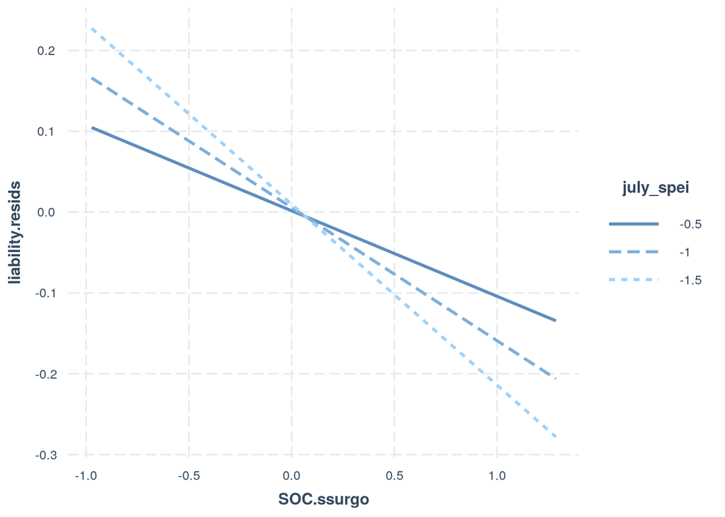

```r
interactions::interact_plot(model = m, pred = SOC.ssurgo, modx = july_spei, modx.values = c(-1.5,-1, -0.5))
```

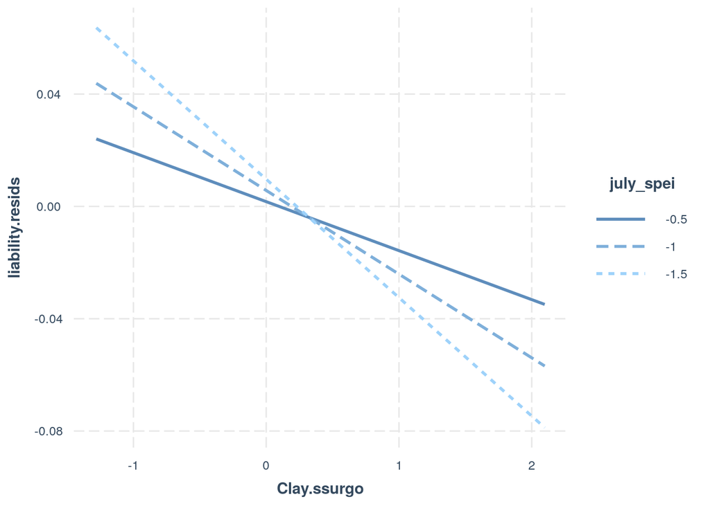

```r
interactions::interact_plot(model = m, pred = Clay.ssurgo, modx = july_spei, modx.values = c(-1.5,-1, -0.5))
```

Model coefficients suggest that SOC and clay both interact with drought to reduce payouts as drought intensity increases, but the effect of SOC is stronger (coefficient is higher). In addition, after accounting for the impact of liabilities, drought becomes a less reliable predictor of indemnities (p value goes up).

To test the efficacy of this approach with residuals, we’ll also test if specifiying liabilities as a fixed effect produces similar results.

```r
m <- all.data.stan %>%
  lmerTest::lmer(data = ., formula = Indemnity.drought ~ Liability.drought+july_spei*SOC.ssurgo*Clay.ssurgo +
                   (1|Order.ssurgo))

summary(m)
```

```
## Linear mixed model fit by REML. t-tests use Satterthwaite's method [
## lmerModLmerTest]
## Formula: Indemnity.drought ~ Liability.drought + july_spei * SOC.ssurgo *
##     Clay.ssurgo + (1 | Order.ssurgo)
##    Data: .
##
## REML criterion at convergence: -903
##
## Scaled residuals:
##      Min       1Q   Median       3Q      Max
## -17.5461  -0.0759   0.0372   0.1117  25.3800
##
## Random effects:
##  Groups       Name        Variance  Std.Dev.
##  Order.ssurgo (Intercept) 0.0001428 0.01195
##  Residual                 0.0521080 0.22827
## Number of obs: 8329, groups:  Order.ssurgo, 6
##
## Fixed effects:
##                                    Estimate Std. Error         df t value
## (Intercept)                      -1.910e-03  6.212e-03  2.533e+00  -0.307
## Liability.drought                 9.033e-01  5.616e-03  8.228e+03 160.840
## july_spei                        -1.276e-03  5.679e-03  8.282e+03  -0.225
## SOC.ssurgo                       -4.787e-02  6.526e-03  1.466e+02  -7.335
## Clay.ssurgo                      -5.267e-03  6.190e-03  2.699e+02  -0.851
## july_spei:SOC.ssurgo              1.244e-01  1.117e-02  8.319e+03  11.134
## july_spei:Clay.ssurgo             2.503e-02  1.110e-02  8.320e+03   2.254
## SOC.ssurgo:Clay.ssurgo           -1.450e-03  1.340e-02  1.826e+03  -0.108
## july_spei:SOC.ssurgo:Clay.ssurgo -3.883e-02  2.677e-02  8.317e+03  -1.450
##                                  Pr(>|t|)
## (Intercept)                        0.7820
## Liability.drought                 < 2e-16 ***
## july_spei                          0.8221
## SOC.ssurgo                       1.39e-11 ***
## Clay.ssurgo                        0.3955
## july_spei:SOC.ssurgo              < 2e-16 ***
## july_spei:Clay.ssurgo              0.0242 *
## SOC.ssurgo:Clay.ssurgo             0.9138
## july_spei:SOC.ssurgo:Clay.ssurgo   0.1470
## ---
## Signif. codes:  0 '***' 0.001 '**' 0.01 '*' 0.05 '.' 0.1 ' ' 1
##
## Correlation of Fixed Effects:
##             (Intr) Lblty. jly_sp SOC.ss Cly.ss jl_:SOC. jl_:C. SOC.:C
## Lblty.drght  0.020
## july_spei    0.021  0.384
## SOC.ssurgo   0.127 -0.050 -0.014
## Clay.ssurgo -0.131 -0.010  0.005 -0.106
## jly_sp:SOC.  0.002  0.188  0.153  0.016 -0.006
## jly_sp:Cly.  0.002  0.009 -0.189 -0.018  0.053 -0.276
## SOC.ssrg:C. -0.055 -0.011 -0.013 -0.122  0.374  0.013    0.010
## jl_:SOC.:C. -0.008  0.012 -0.259  0.007  0.004 -0.247    0.504  0.058
```

Model coefficients change only very slightly, and liabilties emerge as a very strong effect (highest beta coefficient, least p value).

However, given that there are a significant number of observations for which indemnities are zero or very close to zero, simple LMEs are likely not appropriate for these questions. Tobit regression is an approach for when the dependent variable is zero-inflated (or has a distinct lower limit after data are standardized) and continuous.

```r
m <- all.data.stan %>%
  vglm(data = ., formula = Indemnity.drought ~ Liability.drought+july_spei*SOC.ssurgo*Clay.ssurgo,
       tobit(Lower =  -0.1076599716, type.fitted = "uncensored"), maxit = 50, smart = TRUE)

summary(m)
```

```
##
## Call:
## vglm(formula = Indemnity.drought ~ Liability.drought + july_spei *
##     SOC.ssurgo * Clay.ssurgo, family = tobit(Lower = -0.1076599716,
##     type.fitted = "uncensored"), data = ., smart = TRUE, maxit = 50)
##
## Pearson residuals:
##                 Min      1Q  Median      3Q    Max
## mu          -15.404 -0.5719  0.1686  0.3965  22.19
## loglink(sd)  -1.009 -0.9511 -0.8725 -0.2848 347.54
##
## Coefficients:
##                                   Estimate Std. Error  z value Pr(>|z|)
## (Intercept):1                    -0.063310   0.003388  -18.685  < 2e-16
## (Intercept):2                    -1.343527   0.010738 -125.120  < 2e-16
## Liability.drought                 0.899612   0.006564  137.049  < 2e-16
## july_spei                        -0.096823   0.007461  -12.977  < 2e-16
## SOC.ssurgo                       -0.023410   0.006943   -3.372 0.000747
## Clay.ssurgo                       0.005491   0.007549    0.727 0.467009
## july_spei:SOC.ssurgo              0.158852   0.014605   10.877  < 2e-16
## july_spei:Clay.ssurgo             0.050453   0.014352    3.515 0.000439
## SOC.ssurgo:Clay.ssurgo            0.000882   0.017362    0.051 0.959483
## july_spei:SOC.ssurgo:Clay.ssurgo -0.079942   0.034757   -2.300 0.021448
##
## (Intercept):1                    ***
## (Intercept):2                    ***
## Liability.drought                ***
## july_spei                        ***
## SOC.ssurgo                       ***
## Clay.ssurgo
## july_spei:SOC.ssurgo             ***
## july_spei:Clay.ssurgo            ***
## SOC.ssurgo:Clay.ssurgo
## july_spei:SOC.ssurgo:Clay.ssurgo *
## ---
## Signif. codes:  0 '***' 0.001 '**' 0.01 '*' 0.05 '.' 0.1 ' ' 1
##
## Names of linear predictors: mu, loglink(sd)
##
## Log-likelihood: -1557.191 on 16648 degrees of freedom
##
## Number of Fisher scoring iterations: 22
##
## No Hauck-Donner effect found in any of the estimates
```

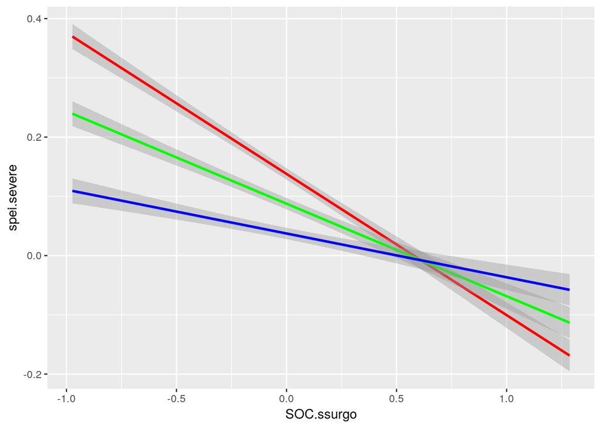

```r
all.data.stan %>%
  mutate(spei.minimal = as.data.frame(predict(m,newdata=transform(all.data.stan,july_spei=-1)))$mu,
         spei.moderate = as.data.frame(predict(m,newdata=transform(all.data.stan,july_spei=-1.5)))$mu,
         spei.severe = as.data.frame(predict(m,newdata=transform(all.data.stan,july_spei=-2)))$mu) %>%
  ggplot(.) +
  geom_smooth(method = "lm", aes(x =SOC.ssurgo, y= spei.severe), color = "red")+
  geom_smooth(method = "lm", aes(x =SOC.ssurgo, y= spei.moderate), color = "green")+
  geom_smooth(method = "lm", aes(x =SOC.ssurgo, y= spei.minimal), color = "blue")
```

Using a tobit regression, the effects structure and size of coefficients remains largely the same. An interaction effect for SOC and drought emerges, and in terms of directionality it is similar to simpler models- SOC reduces payouts under adverse conditions.

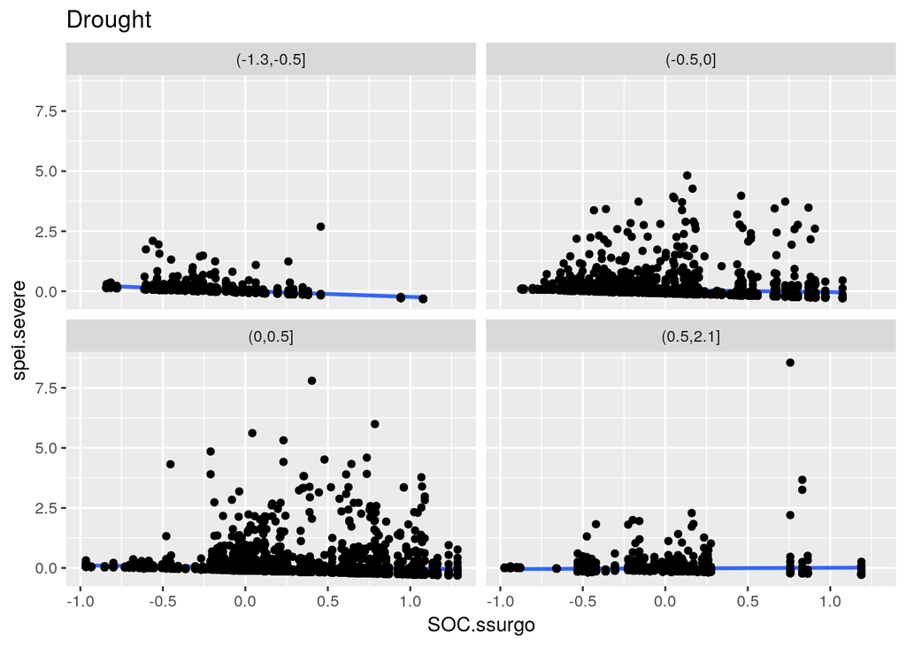

```r
all.data.stan %>%
  mutate(spei.severe = as.data.frame(predict(m,newdata=transform(all.data.stan,july_spei=-1)))$mu,
         fct = cut(Clay.ssurgo, breaks = c(-1.3,-0.5,0,0.5,2.1))) %>%
  ggplot(.) +
  geom_smooth(method = "lm", aes(x =SOC.ssurgo, y= spei.severe))+
  geom_jitter(aes(x =SOC.ssurgo, y= spei.severe))+
  facet_wrap(facets = "fct")+
  ggtitle("Drought")
```

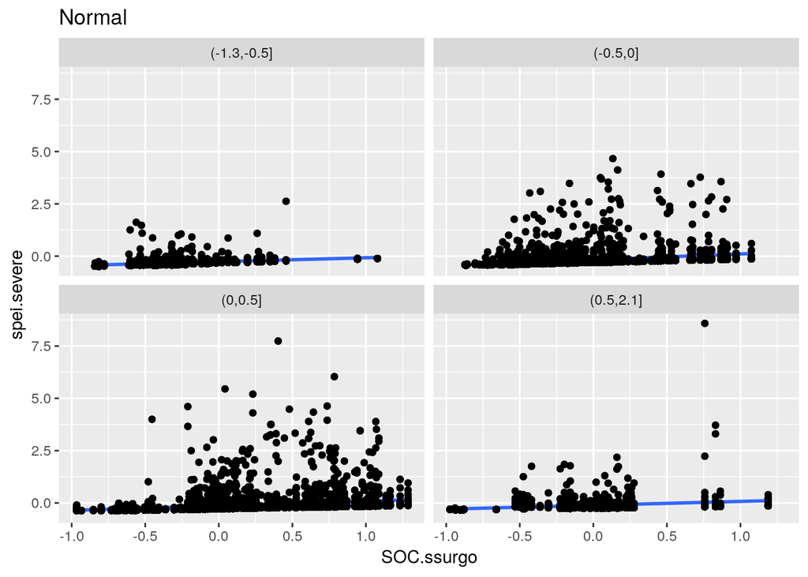

```r
all.data.stan %>%
  mutate(spei.severe = as.data.frame(predict(m,newdata=transform(all.data.stan,july_spei=1)))$mu,
         fct = cut(Clay.ssurgo, breaks = c(-1.3,-0.5,0,0.5,2.1))) %>%
  ggplot(.) +
  geom_smooth(method = "lm", aes(x =SOC.ssurgo, y= spei.severe))+
  geom_jitter(aes(x =SOC.ssurgo, y= spei.severe))+
  geom_jitter(aes(x =SOC.ssurgo, y= spei.severe))+
  facet_wrap(facets = "fct")+
  ggtitle("Normal")
```

In addition to a tobit model, we’ll run a Heckman selection model. A Heckman selection model is similar but rather than assuming that the process that creates “zeroes” in the dependent variable is latent, it assumes that “zero” observations of the dependent variable are based on some selection/threshold process that can be modeled by the data in hand. In this case, we’ll model a selection process in which payouts are non-zero as a function of drought, and then any non-zero payouts are further predicted by a combination of drought and soil properties.

```r
m.sel <- all.data.stan %>%
  mutate(non.zero = as.logical(all.data.stan$Indemnity.drought != -0.1076599716)) %>%
  selection(data = .,
                   selection = non.zero ~ july_spei,
                   outcome =  Indemnity.drought ~ Liability.drought+july_spei*SOC.ssurgo*Clay.ssurgo,
            method = "2step")

summary(m.sel)
```

```
## --------------------------------------------
## Tobit 2 model (sample selection model)
## 2-step Heckman / heckit estimation
## 8329 observations (2077 censored and 6252 observed)
## 14 free parameters (df = 8316)
## Probit selection equation:
##             Estimate Std. Error t value Pr(>|t|)
## (Intercept)  0.80773    0.01715   47.09   <2e-16 ***
## july_spei   -1.28674    0.03782  -34.02   <2e-16 ***
## Outcome equation:
##                                   Estimate Std. Error t value Pr(>|t|)
## (Intercept)                      -0.244237   0.024162 -10.108  < 2e-16 ***
## Liability.drought                 0.876270   0.010023  87.425  < 2e-16 ***
## july_spei                        -0.306237   0.032640  -9.382  < 2e-16 ***
## SOC.ssurgo                       -0.044455   0.005970  -7.446 1.06e-13 ***
## Clay.ssurgo                      -0.004758   0.006275  -0.758   0.4484
## july_spei:SOC.ssurgo              0.155584   0.017020   9.141  < 2e-16 ***
## july_spei:Clay.ssurgo             0.039632   0.016314   2.429   0.0152 *
## SOC.ssurgo:Clay.ssurgo           -0.009734   0.014897  -0.653   0.5135
## july_spei:SOC.ssurgo:Clay.ssurgo -0.076743   0.040395  -1.900   0.0575 .
## Multiple R-Squared:0.7949,   Adjusted R-Squared:0.7946
##    Error terms:
##               Estimate Std. Error t value Pr(>|t|)
## invMillsRatio  0.58110    0.05604   10.37   <2e-16 ***
## sigma          0.44459         NA      NA       NA
## rho            1.30703         NA      NA       NA
## ---
## Signif. codes:  0 '***' 0.001 '**' 0.01 '*' 0.05 '.' 0.1 ' ' 1
## --------------------------------------------
```

A Heckman selection model produces very similar results to a standard tobit regression, but the p-value of the three-way interaction of drought, SOC, and clay increases. This change suggests that a Heckman selection model is picking up on some dynamic that is poorly described in other models. Looking at the data more closely, two patterns emerge:

1.) Coverage consistency is much higher in the corn belt - growers insure most years rather than on rare drought years, in which yields are likely to be poor. The selection model is capturing that pattern to some degree, but perhaps indirectly. 2.) The majority of clay dominant soils are outside the corn belt.

We’ll apply the same selection model but split by corn belt and non corn belt.

```r
m.CB <- all.data.stan %>%
  filter(Corn.belt == "CB") %>%
  mutate(non.zero = as.logical(.$Indemnity.drought != -0.1076599716)) %>%
  selection(data = .,
                   selection = non.zero ~ july_spei,
                   outcome =  Indemnity.drought ~ Liability.drought+july_spei*SOC.ssurgo*Clay.ssurgo,
            method = "2step")

summary(m.CB)
```

```
## --------------------------------------------
## Tobit 2 model (sample selection model)
## 2-step Heckman / heckit estimation
## 5592 observations (1113 censored and 4479 observed)
## 14 free parameters (df = 5579)
## Probit selection equation:
##             Estimate Std. Error t value Pr(>|t|)
## (Intercept)  1.11399    0.02570   43.34   <2e-16 ***
## july_spei   -1.66350    0.05613  -29.64   <2e-16 ***
## Outcome equation:
##                                   Estimate Std. Error t value Pr(>|t|)
## (Intercept)                      -0.137006   0.015736  -8.707  < 2e-16 ***
## Liability.drought                 0.882694   0.009671  91.275  < 2e-16 ***
## july_spei                        -0.238373   0.027709  -8.603  < 2e-16 ***
## SOC.ssurgo                       -0.050664   0.010155  -4.989 6.26e-07 ***
## Clay.ssurgo                      -0.007751   0.011324  -0.684  0.49370
## july_spei:SOC.ssurgo              0.239180   0.022941  10.426  < 2e-16 ***
## july_spei:Clay.ssurgo             0.042106   0.023870   1.764  0.07780 .
## SOC.ssurgo:Clay.ssurgo            0.029625   0.028607   1.036  0.30044
## july_spei:SOC.ssurgo:Clay.ssurgo -0.179732   0.063505  -2.830  0.00467 **
## Multiple R-Squared:0.8022,   Adjusted R-Squared:0.8018
##    Error terms:
##               Estimate Std. Error t value Pr(>|t|)
## invMillsRatio  0.39728    0.04347   9.139   <2e-16 ***
## sigma          0.36661         NA      NA       NA
## rho            1.08365         NA      NA       NA
## ---
## Signif. codes:  0 '***' 0.001 '**' 0.01 '*' 0.05 '.' 0.1 ' ' 1
## --------------------------------------------
```

```r
m.NCB <- all.data.stan %>%
  filter(Corn.belt == "NCB") %>%
  mutate(non.zero = as.logical(.$Indemnity.drought != -0.1076599716)) %>%
  selection(data = .,
                   selection = non.zero ~ july_spei,
                   outcome =  Indemnity.drought ~ Liability.drought+july_spei*SOC.ssurgo*Clay.ssurgo,
            method = "2step")

summary(m.NCB)
```

```
## --------------------------------------------
## Tobit 2 model (sample selection model)
## 2-step Heckman / heckit estimation
## 2737 observations (964 censored and 1773 observed)
## 14 free parameters (df = 2724)
## Probit selection equation:
##             Estimate Std. Error t value Pr(>|t|)
## (Intercept)  0.42224    0.02597   16.26   <2e-16 ***
## july_spei   -1.03046    0.05729  -17.99   <2e-16 ***
## Outcome equation:
##                                   Estimate Std. Error t value Pr(>|t|)
## (Intercept)                      -0.155174   0.053021  -2.927 0.003455 **
## Liability.drought                 0.770711   0.019174  40.197  < 2e-16 ***
## july_spei                        -0.183669   0.049114  -3.740 0.000188 ***
## SOC.ssurgo                       -0.005268   0.007837  -0.672 0.501537
## Clay.ssurgo                       0.010734   0.006716   1.598 0.110119
## july_spei:SOC.ssurgo             -0.035328   0.021643  -1.632 0.102741
## july_spei:Clay.ssurgo            -0.014463   0.016962  -0.853 0.393928
## SOC.ssurgo:Clay.ssurgo            0.007464   0.015024   0.497 0.619381
## july_spei:SOC.ssurgo:Clay.ssurgo -0.052022   0.040047  -1.299 0.194048
## Multiple R-Squared:0.6684,   Adjusted R-Squared:0.6667
##    Error terms:
##               Estimate Std. Error t value Pr(>|t|)
## invMillsRatio  0.28176    0.09029   3.121  0.00182 **
## sigma          0.23742         NA      NA       NA
## rho            1.18678         NA      NA       NA
## ---
## Signif. codes:  0 '***' 0.001 '**' 0.01 '*' 0.05 '.' 0.1 ' ' 1
## --------------------------------------------
```

Coefficient structures hold for the Corn Belt but for counties outside the corn belt the only significant/strong predictors of payouts are initial liabilities and drought conditions. It’s hard to discern if this change is primarily because of soil factors or if it’s still a consequence of coverage patterns.

CONCLUSIONS:

Using multiple different modeling approaches that account for the fact that payouts are first and foremost afunction of the amount of coverage in dollars in a given county, we demonstrate that SOC has a mitigating impact on payouts under drought conditions. In some modeling approaches this impact is also conditional on native clay content such that the impact is greater on soils with lower clay.